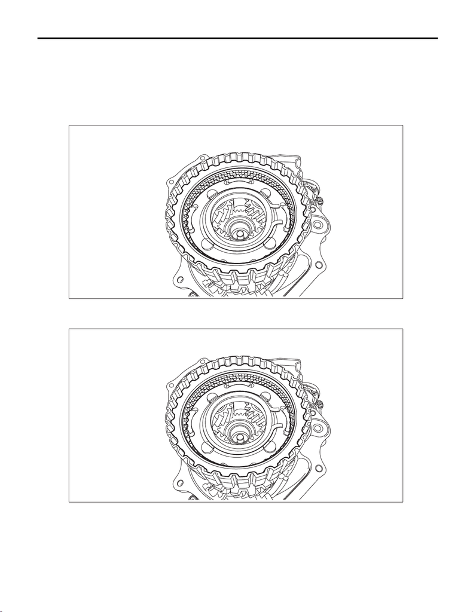

Transfer Clutch

CONTINUOUSLY VARIABLE TRANSMISSION

30.Transfer Clutch

A: REMOVAL

2) Remove the extension case. <Ref. to CVT(TR690)-142, REMOVAL, Extension Case.>

3) Remove the rear drive shaft. <Ref. to CVT(TR690)-146, REMOVAL, Rear Drive Shaft.>

4) Remove the transfer clutch assembly.

B: INSTALLATION

1) Install the transfer clutch assembly.

3) Attach the selected driven plate No. 3 to the center differential assembly.

4) Install the rear drive shaft. <Ref. to CVT(TR690)-146, INSTALLATION, Rear Drive Shaft.>

5) Install the extension case. <Ref. to CVT(TR690)-143, INSTALLATION, Extension Case.>

AT-07360

AT-07360

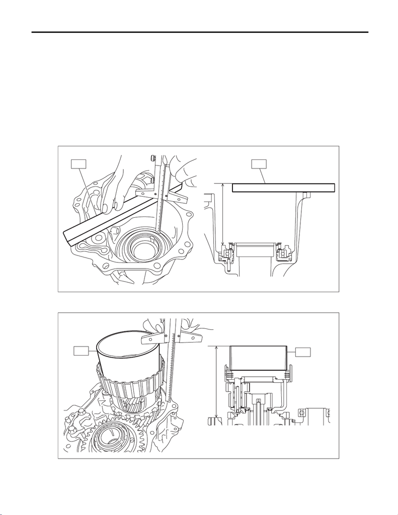

Transfer Clutch

CONTINUOUSLY VARIABLE TRANSMISSION

C: INSPECTION

• Inspect the drive plate facing for wear and damage.

• Driven plate for discoloration (burned color)

• Check the lip seal for damage.

D: ADJUSTMENT

1) Install the drive plate and driven plate to the center differential carrier.

2) Using the ST, measure depth “A” from the end surface of ST to the transfer clutch piston.

ST 499575400 GAUGE

3) Using the ST, measure the height “B” from the mating surface of intermediate case to the end surface of ST.

ST 398744300 PISTON GUIDE

AT-07395

ST

A

ST

AT-07394

ST

B

ST

[figure not shown]

Transfer Clutch

CONTINUOUSLY VARIABLE TRANSMISSION

4) Obtain the thickness of driven plate No. 3 using the following formula to select one driven plate No. 3.

T mm = (A – 15) – (B – 50) + 0.38 – (0.05 — 0.25)

[T in = (A – 0.591) – (B – 1.97) + 0.0149 – (0.002 — 0.01)]

A: Depth from the ST end surface to the transfer clutch piston

B: Height from the mating surface of the intermediate case to the ST end face

0.38 mm (0.0149 in): Thickness of gasket

15 mm (0.591 in): Thickness of ST

50 mm (1.97 in): Thickness of ST

0.05 — 0.25 mm (0.002 — 0.01 in): Clearance

Driven plate No. 3

Part No. Thickness mm (in)

31589AA150 1.6 (0.063)

31589AA160 2.0 (0.079)

31589AA170 2.4 (0.094)

31589AA180 2.8 (0.110)